# Group 6 EDA

2025-02-21

## Introduction

**Project Goal:**  
Identify characteristics of customers that order above a specific threshold annually to determine what might indicate “high growth potential” in customers below the threshold.

**Business Problem Summary:**  
Swire Coca-Cola wants to optimize logistic transport costs by changing some direct delivery (“red truck”) customers to a third-party delivery (“white truck”). They need to identify characteristics of customers which order greater than 400 gallons of product per year in order to determine which customers below this threshold might have “high growth potential”. These “high growth potential” customers may exceed the 400 gallon threshold in the future if they continue with red truck delivery and business support services instead of being swapped to white truck.

**Analytics Problem Summary:**  
Create a supervised classification model to predict the categories of customers based on historical sales data and customer characteristics. The categories of the target variable will be “above 400 gal threshold” and “below 400 gal threshold” of average gallons ordered per year, or alternatively, average gallons ordered per year can be used to create different threshold or category levels. The model must have interpretable results, especially feature importance.

**Notebook Purpose:**  
This notebook will include exploratory data analysis (EDA) to prepare for modeling.

**Questions:**

- Describe data:
  - What is the structure of the data?
  - What is the target variable?
    - Is the data unbalanced with respect to the target variable?
    - What would the accuracy be with a majority class classifier?
  - What kinds of predictor variables are there?
  - What features can we pull from categorical factor or text variables?
  - Is there a majority class in any factor feature?
  - Is there data missing from the provided datasets?
    - Will the missing data have impacts on our analysis or can it be ignored?
- Clean data:
  - Should any numeric or character fields be factored? (in case chosen model doesn’t automatically factor)
  - What columns have NAs?
  - Can the NAs be explained?
  - Do any columns have a significant proportion of unexplained NAs so should be excluded?
  - Can NAs be reasonably imputed?
  - Are there any mistaken values?
  - Are there any outlier values that may skew a predictor?
- Explore data relationships:
  - What may be strong predictors of the target variable?
  - Are there relationships between any predictor variables (e.g. multicollinearity)?
  - What feature engineering can be done?
  - Does log transformation of predictors or target help them correlate better?

# Get Data

## Load in all datasets

```r
delivery_data_raw <- read.csv('C:/Users/daniel.powell/Documents/R/Data/delivery_cost_data.csv')
customer_profile_raw <- read.csv('C:/Users/daniel.powell/Documents/R/Data/customer_profile.csv')
customer_address_and_zip_raw <- read.csv('C:/Users/daniel.powell/Documents/R/Data/customer_address_and_zip_mapping.csv')
transactional_data_raw <- read.csv('C:/Users/daniel.powell/Documents/R/Data/transactional_data.csv')
```

# Describe Data

## Customer Profile

This dataset contains detailed customer information, ranging from onboarding to purchasing behavior. Each customer is assigned a unique ID, and customers with multiple locations have a primary group number. If a customer isn’t affiliated with others, this field will contain NA. Additional data includes the customer’s onboarding date, first delivery date, industry, whether a customer is a local market partner, and whether or not they purchase CO2 products. It also includes the customer’s associated ZIP code, which could be useful for later joining with the delivery dataset.

## Customer Address

This dataset maps ZIP codes to full address information. While the ZIP codes are real, they do not represent the actual delivery locations, protecting the privacy of the company’s data. This information could be valuable if location is found to play a significant role in customer growth potential during exploration.

## Transactional Data

This dataset provides detailed transaction-level information, including order quantities and delivery metrics. It records the transaction date, customer ID, and order details from placement to delivery. All cases have been converted to standard physical cases, where one case equals one gallon, allowing for easy combination of cases and gallons into a total amount. It’s important to note that delivery data is stored separately from order data, which should be kept in mind during analysis.

## Delivery Cost Data

This dataset includes information on volume ranges by category and cold drink channel, along with cost per unit and median delivery costs by category. However, this dataset focuses more on general delivery metrics than on individual customer performance, which is the primary focus of this analysis. Therefore, it has been excluded from this analysis. If further exploration suggests it’s necessary, this dataset will be reconsidered for inclusion.

# Clean Data

## Joining Datasets

```r
#join customer address to customer profile
customers_raw_joined <- left_join(customer_profile_raw, customer_address_and_zip_raw, by =c('ZIP_CODE' = 'zip'))

#customer joined with transactions
customers_trans_joined <- left_join(transactional_data_raw, customers_raw_joined, by ='CUSTOMER_NUMBER')
```

## Casting Data Types

Now that we have most of our data in a single dataset, let’s transform our character variables into factors or other datatypes where appropriate.

```r
#get character columns
cust_tran_chr_cols <- names(customers_trans_joined)[sapply(customers_trans_joined, is.character)]
str(customers_trans_joined[cust_tran_chr_cols])
```

```
## 'data.frame':    1045540 obs. of  9 variables:
##  $ TRANSACTION_DATE   : chr  "1/5/2023" "1/6/2023" "1/9/2023" "1/11/2023" ...
##  $ ORDER_TYPE         : chr  "MYCOKE LEGACY" "MYCOKE LEGACY" "MYCOKE LEGACY" "SALES REP" ...
##  $ FREQUENT_ORDER_TYPE: chr  "SALES REP" "OTHER" "MYCOKE360" "SALES REP" ...
##  $ FIRST_DELIVERY_DATE: chr  "5/7/2021" "3/23/2018" "4/12/2021" "5/5/2017" ...
##  $ ON_BOARDING_DATE   : chr  "4/2/2021" "12/8/2015" "1/26/2021" "2/28/1997" ...
##  $ COLD_DRINK_CHANNEL : chr  "DINING" "WELLNESS" "DINING" "BULK TRADE" ...
##  $ TRADE_CHANNEL      : chr  "COMPREHENSIVE DINING" "HEALTHCARE" "FAST CASUAL DINING" "GENERAL" ...
##  $ SUB_TRADE_CHANNEL  : chr  "FSR - MISC" "OTHER HEALTHCARE" "OTHER FAST FOOD" "COMPREHENSIVE PROVIDER" ...
##  $ full.address       : chr  "66955,Mahaska,Kansas,KS,Washington,201,39.9845,-97.3453" "41603,Banner,Kentucky,KY,Floyd,71,37.5707,-82.6806" "01824,Chelmsford,Massachusetts,MA,Middlesex,17,42.5911,-71.3556" "01337,Bernardston,Massachusetts,MA,Franklin,11,42.6952,-72.5772" ...
```

```r
#convert dates to dates
date_columns_tran_cust <- c('TRANSACTION_DATE', 'FIRST_DELIVERY_DATE', 'ON_BOARDING_DATE')
customers_trans_joined_dates <- customers_trans_joined %>%
  mutate(across(all_of(date_columns_tran_cust), ~ case_when(
    TRUE ~ as.Date(., format = "%m/%d/%Y")
  )))
#convert remain chr to factors excluding full address
customers_trans_joined_factored <- customers_trans_joined_dates %>%
  mutate(across(where(is.character) & !matches("full.address"), as.factor))
#confirm factored and dates formatted
str(customers_trans_joined_factored)
```

```
## 'data.frame':    1045540 obs. of  22 variables:
##  $ TRANSACTION_DATE    : Date, format: "2023-01-05" "2023-01-06" ...
##  $ WEEK                : int  1 1 2 2 3 4 4 4 4 5 ...
##  $ YEAR                : int  2023 2023 2023 2023 2023 2023 2023 2023 2023 2023 ...
##  $ CUSTOMER_NUMBER     : int  501202893 500264574 501174701 600586532 501014325 600567384 501363682 500245736 501100933 501372917 ...
##  $ ORDER_TYPE          : Factor w/ 7 levels "CALL CENTER",..: 3 3 3 7 7 1 3 1 1 3 ...
##  $ ORDERED_CASES       : num  1 12.5 2 18 29 1.5 6 0 4 18 ...
##  $ LOADED_CASES        : num  1 12.5 2 16 29 1.5 5 0 1 17 ...
##  $ DELIVERED_CASES     : num  1 12.5 2 16 29 1.5 5 0 1 17 ...
##  $ ORDERED_GALLONS     : num  90 0 0 2.5 0 0 0 25 0 0 ...
##  $ LOADED_GALLONS      : num  90 0 0 2.5 0 0 0 25 0 0 ...
##  $ DELIVERED_GALLONS   : num  90 0 0 2.5 0 0 0 25 0 0 ...
##  $ PRIMARY_GROUP_NUMBER: int  NA 1894 NA 8397 1993 437 NA NA NA NA ...
##  $ FREQUENT_ORDER_TYPE : Factor w/ 6 levels "CALL CENTER",..: 6 5 4 6 6 6 6 5 6 6 ...
##  $ FIRST_DELIVERY_DATE : Date, format: "2021-05-07" "2018-03-23" ...
##  $ ON_BOARDING_DATE    : Date, format: "2021-04-02" "2015-12-08" ...
##  $ COLD_DRINK_CHANNEL  : Factor w/ 9 levels "ACCOMMODATION",..: 4 8 4 2 6 6 4 4 4 4 ...
##  $ TRADE_CHANNEL       : Factor w/ 26 levels "ACADEMIC INSTITUTION",..: 5 12 8 9 10 26 8 17 8 17 ...
##  $ SUB_TRADE_CHANNEL   : Factor w/ 48 levels "ASIAN FAST FOOD",..: 13 31 27 9 28 41 42 26 18 26 ...
##  $ LOCAL_MARKET_PARTNER: logi  TRUE TRUE TRUE FALSE TRUE TRUE ...
##  $ CO2_CUSTOMER        : logi  TRUE FALSE TRUE FALSE FALSE FALSE ...
##  $ ZIP_CODE            : int  66955 41603 1824 1337 67473 67060 21251 1420 40175 67364 ...
##  $ full.address        : chr  "66955,Mahaska,Kansas,KS,Washington,201,39.9845,-97.3453" "41603,Banner,Kentucky,KY,Floyd,71,37.5707,-82.6806" "01824,Chelmsford,Massachusetts,MA,Middlesex,17,42.5911,-71.3556" "01337,Bernardston,Massachusetts,MA,Franklin,11,42.6952,-72.5772" ...
```

```r
#get delivery character columns converted to factors
delivery_data_factored <- delivery_data_raw %>%
  mutate(across(where(is.character) & !matches("Median.Delivery.Cost"), as.factor))
#convert dollars to decimal for median delivery cost
delivery_data_factored$Median.Delivery.Cost <- as.numeric(gsub("[$,]", "", delivery_data_factored$Median.Delivery.Cost))
```

## Check and Correct for Nulls

```r
#check delivery data for nulls
delivery_data_factored %>%
  summarize(across(everything(), ~sum(is.na(.)))) %>%
  print()
```

```
##   Cold.Drink.Channel Vol.Range Applicable.To Median.Delivery.Cost Cost.Type
## 1                  0         0             0                    0         0
```

```r
stg_delivery <- delivery_data_factored
#check tran_cust for nulls
customers_trans_joined_factored %>%
  summarize(across(everything(), ~sum(is.na(.)))) %>%
  print()
```

```
##   TRANSACTION_DATE WEEK YEAR CUSTOMER_NUMBER ORDER_TYPE ORDERED_CASES
## 1                0    0    0               0          0             0
##   LOADED_CASES DELIVERED_CASES ORDERED_GALLONS LOADED_GALLONS DELIVERED_GALLONS
## 1            0               0               0              0                 0
##   PRIMARY_GROUP_NUMBER FREQUENT_ORDER_TYPE FIRST_DELIVERY_DATE ON_BOARDING_DATE
## 1               490895                   0                   0                0
##   COLD_DRINK_CHANNEL TRADE_CHANNEL SUB_TRADE_CHANNEL LOCAL_MARKET_PARTNER
## 1                  0             0                 0                    0
##   CO2_CUSTOMER ZIP_CODE full.address
## 1            0        0            0
```

```r
#create copy of joined and factored dataset
stg_cust_tran <- customers_trans_joined_factored
stg_cust_tran$PRIMARY_GROUP_NUMBER <- factor(ifelse(is.na(stg_cust_tran$PRIMARY_GROUP_NUMBER),  # then convert NAs to...
                                         "NA",                       # ...a character factor level
                                         stg_cust_tran$PRIMARY_GROUP_NUMBER))
#check castings
str(stg_cust_tran)
```

```
## 'data.frame':    1045540 obs. of  22 variables:
##  $ TRANSACTION_DATE    : Date, format: "2023-01-05" "2023-01-06" ...
##  $ WEEK                : int  1 1 2 2 3 4 4 4 4 5 ...
##  $ YEAR                : int  2023 2023 2023 2023 2023 2023 2023 2023 2023 2023 ...
##  $ CUSTOMER_NUMBER     : int  501202893 500264574 501174701 600586532 501014325 600567384 501363682 500245736 501100933 501372917 ...
##  $ ORDER_TYPE          : Factor w/ 7 levels "CALL CENTER",..: 3 3 3 7 7 1 3 1 1 3 ...
##  $ ORDERED_CASES       : num  1 12.5 2 18 29 1.5 6 0 4 18 ...
##  $ LOADED_CASES        : num  1 12.5 2 16 29 1.5 5 0 1 17 ...
##  $ DELIVERED_CASES     : num  1 12.5 2 16 29 1.5 5 0 1 17 ...
##  $ ORDERED_GALLONS     : num  90 0 0 2.5 0 0 0 25 0 0 ...
##  $ LOADED_GALLONS      : num  90 0 0 2.5 0 0 0 25 0 0 ...
##  $ DELIVERED_GALLONS   : num  90 0 0 2.5 0 0 0 25 0 0 ...
##  $ PRIMARY_GROUP_NUMBER: Factor w/ 1021 levels "1001","1006",..: 1021 180 1021 927 223 563 1021 1021 1021 1021 ...
##  $ FREQUENT_ORDER_TYPE : Factor w/ 6 levels "CALL CENTER",..: 6 5 4 6 6 6 6 5 6 6 ...
##  $ FIRST_DELIVERY_DATE : Date, format: "2021-05-07" "2018-03-23" ...
##  $ ON_BOARDING_DATE    : Date, format: "2021-04-02" "2015-12-08" ...
##  $ COLD_DRINK_CHANNEL  : Factor w/ 9 levels "ACCOMMODATION",..: 4 8 4 2 6 6 4 4 4 4 ...
##  $ TRADE_CHANNEL       : Factor w/ 26 levels "ACADEMIC INSTITUTION",..: 5 12 8 9 10 26 8 17 8 17 ...
##  $ SUB_TRADE_CHANNEL   : Factor w/ 48 levels "ASIAN FAST FOOD",..: 13 31 27 9 28 41 42 26 18 26 ...
##  $ LOCAL_MARKET_PARTNER: logi  TRUE TRUE TRUE FALSE TRUE TRUE ...
##  $ CO2_CUSTOMER        : logi  TRUE FALSE TRUE FALSE FALSE FALSE ...
##  $ ZIP_CODE            : int  66955 41603 1824 1337 67473 67060 21251 1420 40175 67364 ...
##  $ full.address        : chr  "66955,Mahaska,Kansas,KS,Washington,201,39.9845,-97.3453" "41603,Banner,Kentucky,KY,Floyd,71,37.5707,-82.6806" "01824,Chelmsford,Massachusetts,MA,Middlesex,17,42.5911,-71.3556" "01337,Bernardston,Massachusetts,MA,Franklin,11,42.6952,-72.5772" ...
```

The only column containing null values is the Primary Group Number in the Customer Profile dataset. Because this variable is the only indicator of whether or not the customer is part of a chain, this information will be kept but the variable will be adjusted to a factor variable to remove the inclusion of NA values.

## Creating Target Variable

According to Swire, the total amount ordered is a combination of ordered gallons and ordered cases. Because of this, we will combine the numerical variables together into an ordered total.

```r
stg_cust_tran_clean <- stg_cust_tran
#created ordered total column
stg_cust_tran_clean$ordered_Total <- stg_cust_tran$ORDERED_CASES + stg_cust_tran$ORDERED_GALLONS
#display summary stats
summary(stg_cust_tran_clean$ordered_Total)
```

```
##     Min.  1st Qu.   Median     Mean  3rd Qu.     Max.
##    0.000    8.547   15.500   36.725   30.000 8479.888
```

Aggregate gallons per year to get a feature for average per year per customer and create a binary of below or above the 400 gallon per year threshold as a potential target variable.

```r
# create summary dataset of average ordered gallons
cust_gallons <- stg_cust_tran_clean %>%
  group_by(CUSTOMER_NUMBER) %>%    # aggregate by customer
  summarise(total_gal_2023 = (sum(ORDERED_CASES[YEAR == 2023]) + sum(ORDERED_GALLONS[YEAR == 2023])),
            total_gal_2024 = (sum(ORDERED_CASES[YEAR == 2024]) + sum(ORDERED_GALLONS[YEAR == 2024])),
            avg_gal_per_year = (total_gal_2023 + total_gal_2024)             # calculate total gallons
                                /2) %>%                                      # divide by 2 years
  mutate(threshold_400_gal = ifelse(avg_gal_per_year >= 400,
                                    TRUE,            # if equal or above 400 gal, meets threshold
                                    FALSE)           # if below 400 gal, does not meet threshold
         )

# add the new data to the raw customer profile + address
cust_profile_target <- merge(x = customers_raw_joined,
                              y = cust_gallons,
                              by = "CUSTOMER_NUMBER",
                              all.x = TRUE)

# clean that new customer profile dataset
cust_profile_target_clean <- cust_profile_target %>%
  mutate(CUSTOMER_NUMBER = factor(CUSTOMER_NUMBER),
         PRIMARY_GROUP_NUMBER = ifelse(is.na(PRIMARY_GROUP_NUMBER),  # then convert NAs to...
                                         "NA",                       # ...a character factor level
                                         PRIMARY_GROUP_NUMBER),
         PRIMARY_GROUP_NUMBER = factor(PRIMARY_GROUP_NUMBER),        # then factor
         FREQUENT_ORDER_TYPE = factor(FREQUENT_ORDER_TYPE),
         FIRST_DELIVERY_DATE = as.Date(FIRST_DELIVERY_DATE, "%m/%d/%Y"),  # no leading zero on m,d; 4-digit year
         ON_BOARDING_DATE = as.Date(ON_BOARDING_DATE, "%m/%d/%Y"),        # no leading zero on m,d; 4-digit year
         COLD_DRINK_CHANNEL = factor(COLD_DRINK_CHANNEL),
         TRADE_CHANNEL = factor(TRADE_CHANNEL),
         SUB_TRADE_CHANNEL = factor(SUB_TRADE_CHANNEL),
         ZIP_CODE = factor(ZIP_CODE),
         total_gal_2023 = ifelse(is.na(total_gal_2023),             # convert NAs to...
                                 0,                                 # ...0 gallons ordered
                                 total_gal_2023),
         total_gal_2024 = ifelse(is.na(total_gal_2024),             # convert NAs to...
                                 0,                                 # ...0 gallons ordered
                                 total_gal_2024),
         avg_gal_per_year = ifelse(is.na(avg_gal_per_year),         # convert NAs to...
                                   0,                               # ...0 gallons ordered
                                   avg_gal_per_year),
         threshold_400_gal = ifelse(is.na(threshold_400_gal),       # convert NAs to...
                                    FALSE,                          # ...FALSE = below threshold
                                    threshold_400_gal)
  )
```

## Explore Data

### Target Variable Imbalance

the two levels of target 400 gallon threshold classes.

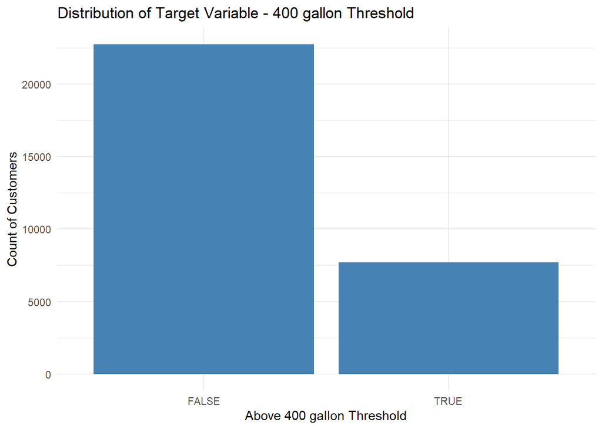

```r
# Create a bar plot using the dataset 'cust_profile_target_clean'
ggplot(cust_profile_target_clean, aes(x = threshold_400_gal)) +

  # Adding a bar geometry to visualize the count of customers in each category of 'threshold_400_gal'
  geom_bar(fill = "steelblue") +

  # Adding title and labels for the x and y axes
  labs(
    title = "Distribution of Target Variable - 400 gallon Threshold",
    x = "Above 400 gallon Threshold",
    y = "Count of Customers"
  ) +

  # Apply a minimal theme for a clean look
  theme_minimal()
```

Check the balance (or imbalance) of the target variable.

```r
# calculate accuracy of majority class prediction
round(
sum(cust_profile_target_clean$threshold_400_gal == FALSE,   # count number of FALSE values
    na.rm = TRUE                                      # ignore NA rows when looking for FALSE
    ) / nrow(cust_profile_target_clean),                    # divide by number of rows total
2)
```

```
## [1] 0.75
```

## Barplots for Categorical Variables

We generated barplots for every categorical variable in the cleaned data frame, using the above described method.

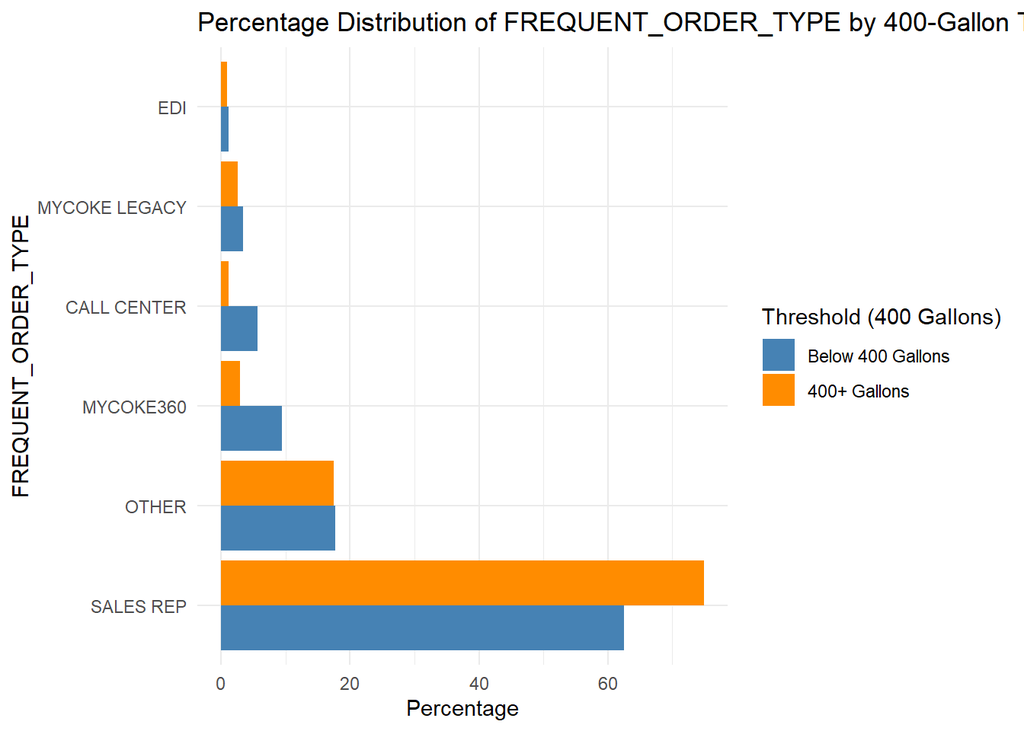

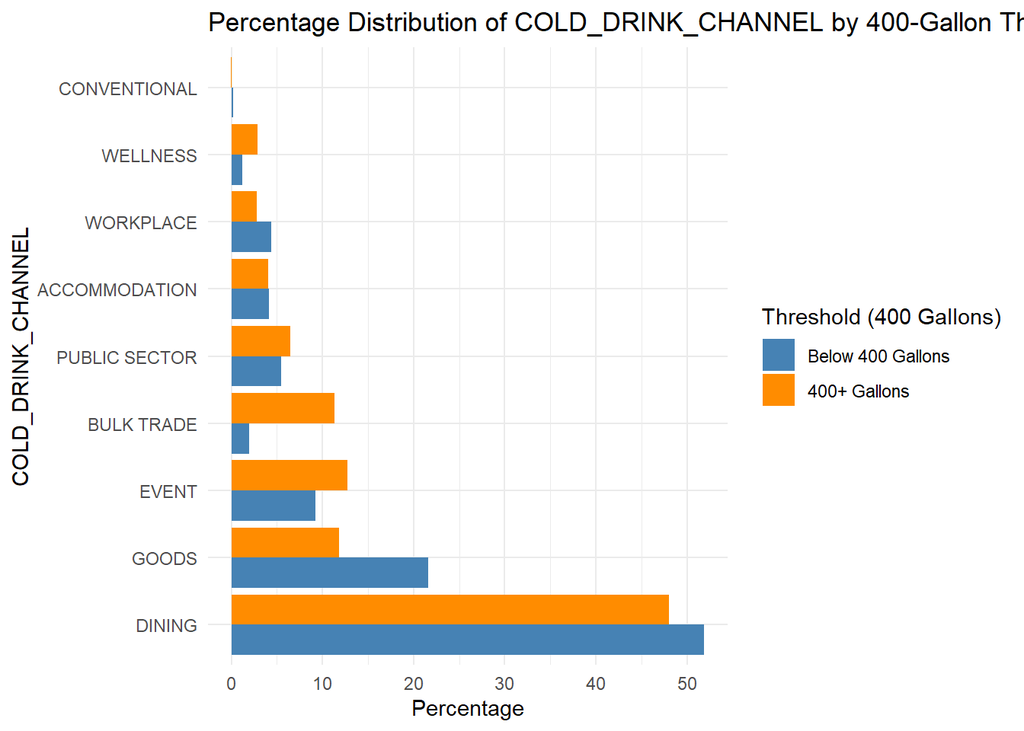

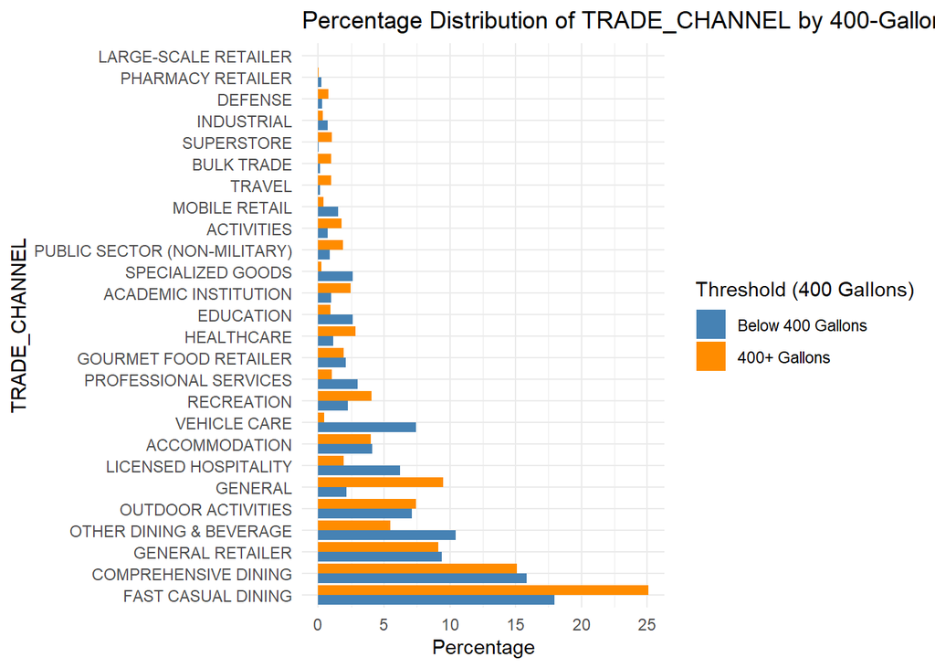

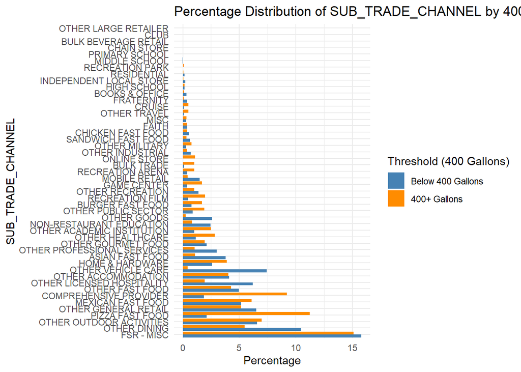

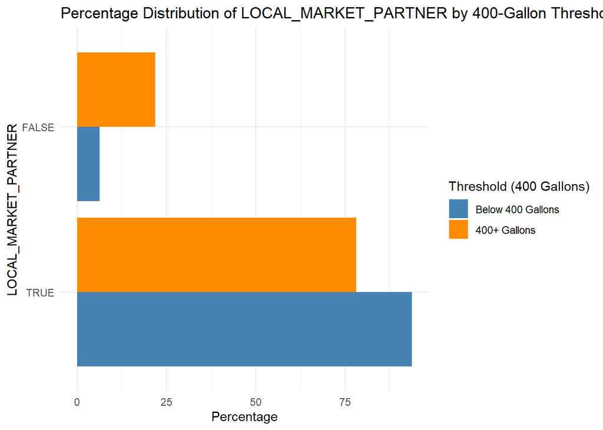

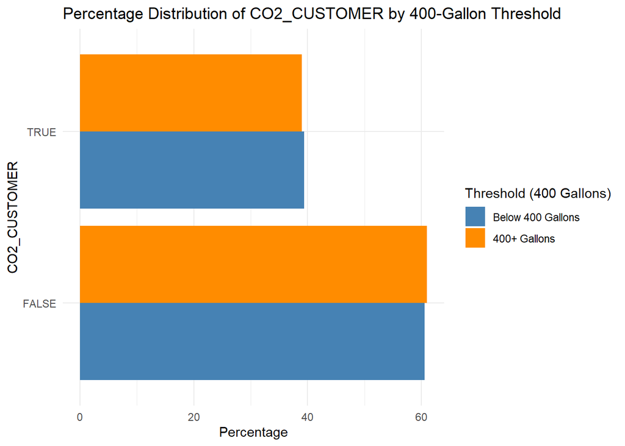

```r
# List of categorical variables (or logical ones) in the dataframe
categorical_vars <- cust_profile_target_clean %>%
  select(where(~ is.factor(.) | is.logical(.))) %>%
  colnames()

# Exclude unwanted variables
excluded_vars <- c("threshold_400_gal", "CUSTOMER_NUMBER", "PRIMARY_GROUP_NUMBER", "ZIP_CODE")
categorical_vars <- setdiff(categorical_vars, excluded_vars)

# Create a plot for each categorical variable
for (var in categorical_vars) {
  # Calculate percentages within each group for the current variable
  distribution <- cust_profile_target_clean %>%
    group_by(threshold_400_gal, !!sym(var)) %>%
    summarise(count = n(), .groups = "drop") %>%
    group_by(threshold_400_gal) %>%
    mutate(percent = count / sum(count) * 100)

  # Create the plot
  p <- ggplot(distribution, aes(x = reorder(!!sym(var), -percent), y = percent, fill = factor(threshold_400_gal))) +
    geom_bar(stat = "identity", position = "dodge") +
    scale_fill_manual(values = c("steelblue", "darkorange"), labels = c("Below 400 Gallons", "400+ Gallons")) +
    labs(title = paste("Percentage Distribution of", var, "by 400-Gallon Threshold"),
         x = var,
         y = "Percentage",
         fill = "Threshold (400 Gallons)") +
    theme_minimal() +
    coord_flip()  # Flip for better readability

  # Print the plot
  print(p)
}
```

This next code makes a similar barplot for each year found within First Delivery Date, to see if more 400+ gallon customers are found in one year vs another.

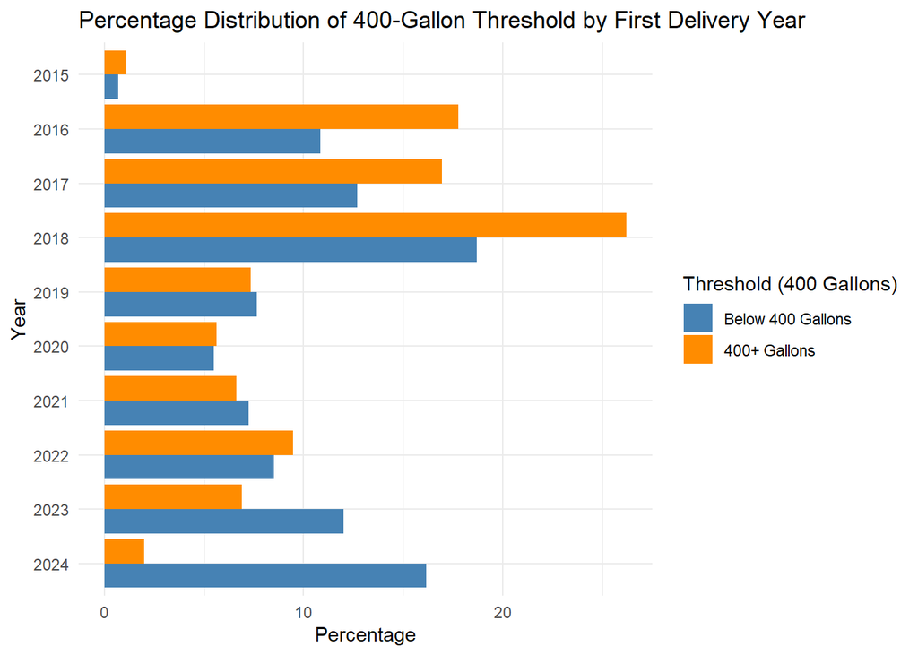

```r
library(forcats)
# Extract year from FIRST_DELIVERY_DATE and treat it as a factor
cust_profile_target_clean <- cust_profile_target_clean %>%
  mutate(FIRST_DELIVERY_YEAR = factor(format(FIRST_DELIVERY_DATE, "%Y")))

# Calculate percentage distribution by FIRST_DELIVERY_YEAR and threshold_400_gal
year_distribution <- cust_profile_target_clean %>%
  group_by(threshold_400_gal, FIRST_DELIVERY_YEAR) %>%
  summarise(count = n(), .groups = "drop") %>%
  group_by(threshold_400_gal) %>%
  mutate(percent = count / sum(count) * 100)

# Create the plot with years in descending order
ggplot(year_distribution, aes(x = fct_rev(FIRST_DELIVERY_YEAR), y = percent, fill = factor(threshold_400_gal))) +
  geom_bar(stat = "identity", position = "dodge") +
  scale_fill_manual(values = c("steelblue", "darkorange"), labels = c("Below 400 Gallons", "400+ Gallons")) +
  labs(title = "Percentage Distribution of 400-Gallon Threshold by First Delivery Year",
       x = "Year",
       y = "Percentage",
       fill = "Threshold (400 Gallons)") +
  theme_minimal() +
  coord_flip()
```

We see a greater percentage of 400+ gallon customers in the mid-to-late 2010s than in more recent years.

## Correlation Matrix

Next is a correlation matrix for the few numeric variables in the dataframe. Not very informative besides to confirm that there aren’t any unexpected collinear relationships going on.

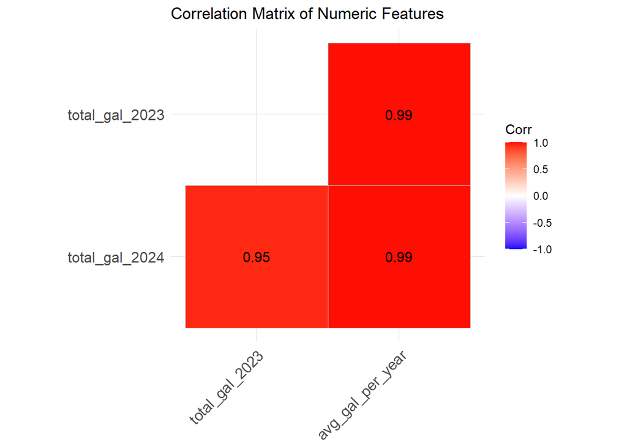

```r
# Select numeric columns from cust_profile_target_clean
numeric_data <- cust_profile_target_clean %>%
  select(total_gal_2023, total_gal_2024, avg_gal_per_year)

# Calculate the correlation matrix
correlation_matrix <- cor(numeric_data, use = "complete.obs")

# Plot the correlation matrix
ggcorrplot(correlation_matrix, hc.order = TRUE, type = "lower", lab = TRUE, title = "Correlation Matrix of Numeric Features")
```

These three numeric variables are all extremely collinear, which we expect as they are related engineered features. We will need to be careful about adding them simultaneously to the same model in the Modeling phase of this project.

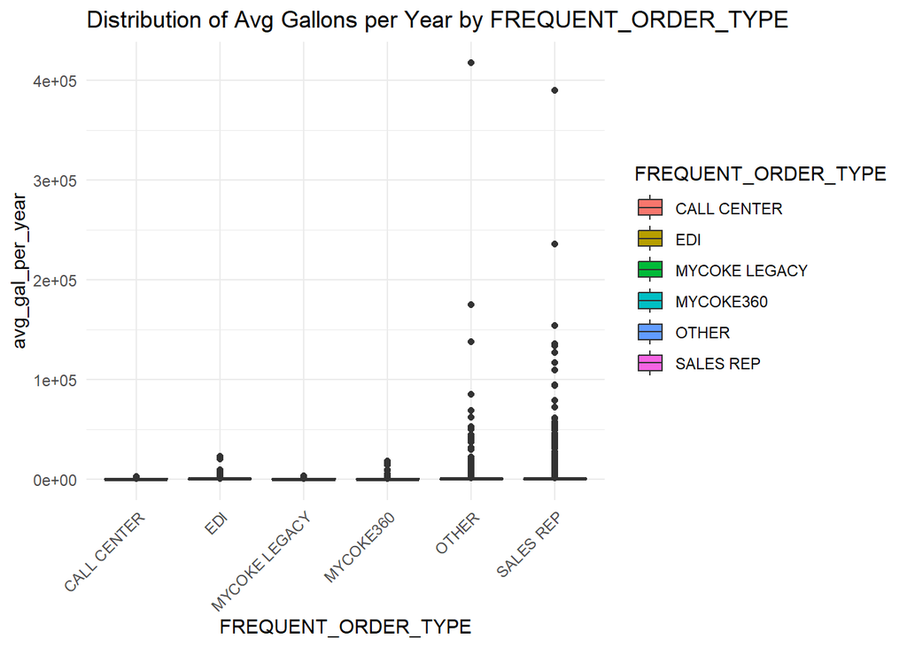

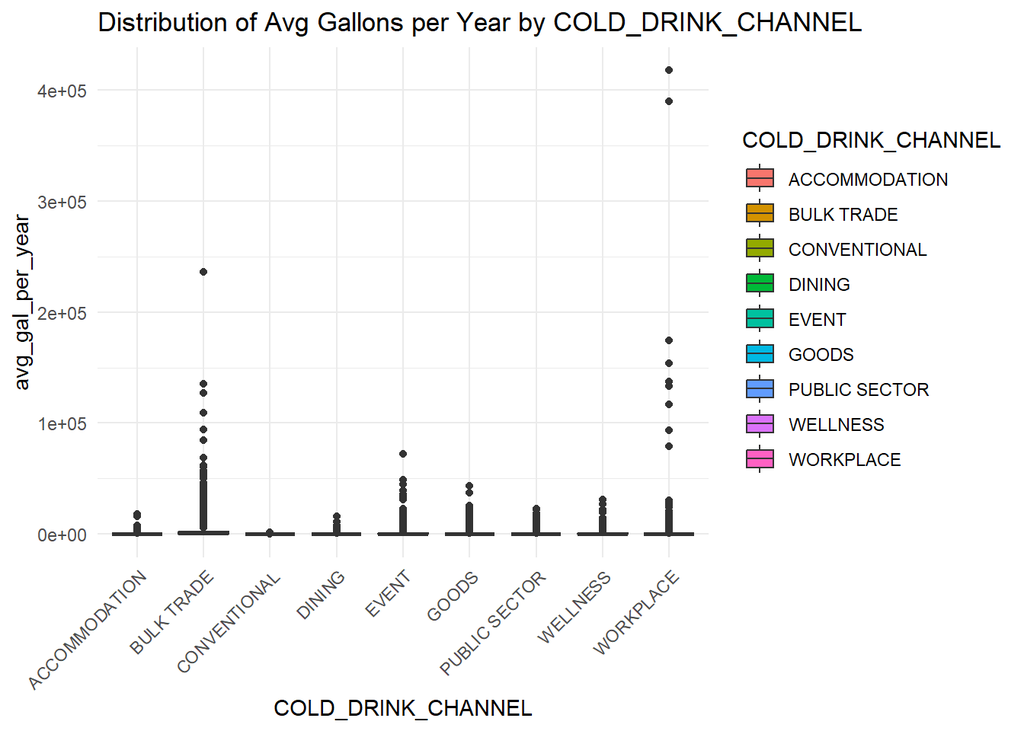

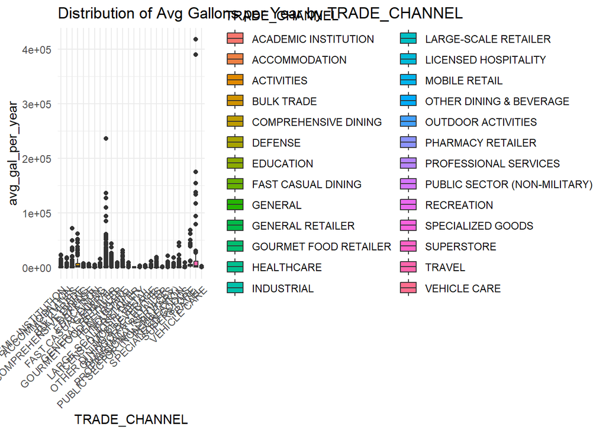

[figure not shown]

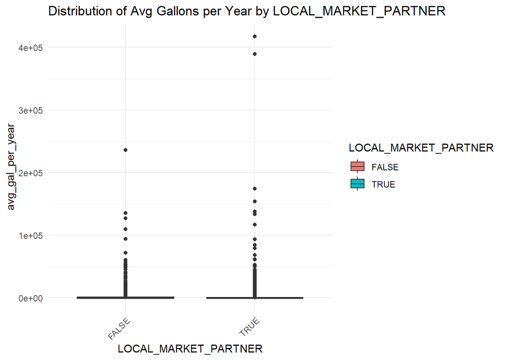

```r
# List of factor variables in your new dataset, excluding threshold_400_gal
factor_vars <- c("FREQUENT_ORDER_TYPE", "COLD_DRINK_CHANNEL", "TRADE_CHANNEL",
                 "SUB_TRADE_CHANNEL", "LOCAL_MARKET_PARTNER")

# Create an empty list to store the plots
plot_list <- list()

# Loop through each factor variable and create a boxplot
for (var in factor_vars) {
  plot <- ggplot(cust_profile_target_clean %>% filter(avg_gal_per_year > 0), aes(x = !!sym(var), y = avg_gal_per_year, fill = !!sym(var))) +
    geom_boxplot() +
    labs(title = paste("Distribution of Avg Gallons per Year by", var)) +
    theme_minimal() +
    theme(axis.text.x = element_text(angle = 45, hjust = 1))  # Rotate x-axis labels for better readability

  # Store the plot in the list
  plot_list[[var]] <- plot
}

# Print all the plots
for (plot in plot_list) {
  print(plot)
}
```

These boxplots suggest that further work to reduce outliers could be warranted before modeling, since the boxes are flattened and condensed at the bottom of their respective graphs.

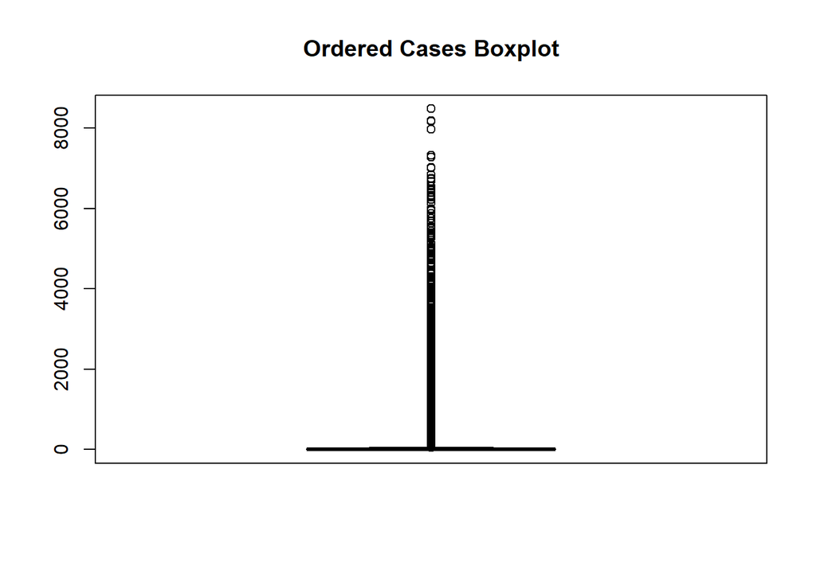

```r
boxplot(stg_cust_tran_clean$ORDERED_CASES, main = "Ordered Cases Boxplot")
```

## Percent Change from 2023 to 2024 as a possible Target

Checking to see how customers either increased or decreased their total order quantities from 2023 to 2024. This will used in conjunction with the 400 gallon threshold to also see what attributes contributed to either a growth or decline. This can be used either a raw number, percentage, or a categorical variable of growth.

```r
#  Calculate total order per year for each customer
customer_year_totals <- stg_cust_tran_clean %>%
  group_by(CUSTOMER_NUMBER, YEAR) %>%                         # Group by customer and year
  summarise(total_order_per_year = sum(ordered_Total, na.rm = TRUE), .groups = "drop")  # Sum for each group

#  Calculate percent change year-over-year for each customer
customer_year_totals <- customer_year_totals %>%
  arrange(CUSTOMER_NUMBER, YEAR) %>%                          # Ensure the data is ordered by customer and year
  group_by(CUSTOMER_NUMBER) %>%                               # Group by customer to calculate percentage change within each group
  mutate(percent_change = ((total_order_per_year - lag(total_order_per_year)) / lag(total_order_per_year)) * 100)  # Calculate YoY change

#  Display results
customer_year_totals %>%
  arrange(CUSTOMER_NUMBER, YEAR) %>%
  head()  # Show first few rows for verification
```

```
## # A tibble: 6 × 4
## # Groups:   CUSTOMER_NUMBER [3]
##   CUSTOMER_NUMBER  YEAR total_order_per_year percent_change
##             <int> <int>                <dbl>          <dbl>
## 1       500245678  2023                370            NA
## 2       500245678  2024                384.            3.65
## 3       500245685  2023                602.           NA
## 4       500245685  2024                482           -19.9
## 5       500245686  2023                 17.5          NA
## 6       500245686  2024                 18.5           5.71
```

Pivoting the previous data to be more readable, this will also be used to create a binary varible for growth, which will be more helpful when joining other attributes to this data.

```r
#  Pivot the data so that each customer has one row with separate columns for each year
customer_year_summary <- customer_year_totals %>%
  select(CUSTOMER_NUMBER, YEAR, total_order_per_year) %>%
  pivot_wider(names_from = YEAR, values_from = total_order_per_year, names_prefix = "total_order_") %>%
  rename(total_order_2023 = total_order_2023, total_order_2024 = total_order_2024)

#  Calculate the percent change between 2023 and 2024
customer_year_summary <- customer_year_summary %>%
  mutate(percent_change = ((total_order_2024 - total_order_2023) / total_order_2023) * 100)

#  Display the result
customer_year_summary %>% head()
```

```
## # A tibble: 6 × 4
## # Groups:   CUSTOMER_NUMBER [6]
##   CUSTOMER_NUMBER total_order_2023 total_order_2024 percent_change
##             <int>            <dbl>            <dbl>          <dbl>
## 1       500245678            370              384.            3.65
## 2       500245685            602.             482           -19.9
## 3       500245686             17.5             18.5           5.71
## 4       500245687            125              148.           18
## 5       500245689            546.             621            13.6
## 6       500245690            325              300.           -7.54
```

### Explore Customer Percent Change

Here we convert the percant change into a categorial variable with grew, declined, or stayed the same. With the overall trend we can see that the majority of customers had a decline (roughly 14,000), about 11,000 grew and only 300 stayed the same. While the growth amount is still healthy, some more background research will need to be done to understand what is driving such a large decline. It might be regional issues, market trend, or change in internal processes.

```r
#  Categorize customers into 'grew', 'declined', or 'stayed_same'
customer_year_summary <- customer_year_summary %>%
  mutate(growth_category = case_when(
    percent_change > 0 ~ "grew",
    percent_change < 0 ~ "declined",
    percent_change == 0 | abs(percent_change) < 0.001 ~ "stayed_same",
    TRUE ~ "unknown"
  ))

#  Count the total number of customers in each category
summary_stats <- customer_year_summary %>%
  ungroup() %>%                      # Remove any grouping from previous steps
  summarise(
    grew = sum(growth_category == "grew"),
    declined = sum(growth_category == "declined"),
    stayed_same = sum(growth_category == "stayed_same")
  )

#  Display the final single-row summary
summary_stats
```

```
## # A tibble: 1 × 3
##    grew declined stayed_same
##   <int>    <int>       <int>
## 1 10897    14053         309
```

### First Delivery & Percent Change

From the graphs, we are also able to see that there are a few outliers in the data that should be considered as they could cause issues in the future when trying to train models.

```r
library(lubridate)
#  Calculate the number of years since first delivery
customer_years <- stg_cust_tran_clean %>%
  select(CUSTOMER_NUMBER, FIRST_DELIVERY_DATE) %>%
  distinct() %>%  # Ensure one row per customer
  mutate(years_since_first_delivery = 2024 - year(as.Date(FIRST_DELIVERY_DATE)))

#  Join with pivoted data containing percent change
customer_summary <- customer_year_summary %>%
  left_join(customer_years, by = "CUSTOMER_NUMBER")

# Group customers by years since first delivery and summarize percent change
summary_by_years <- customer_summary %>%
  group_by(years_since_first_delivery) %>%
  summarise(
    avg_percent_change = mean(percent_change, na.rm = TRUE),
    median_percent_change = median(percent_change, na.rm = TRUE),
    count_customers = n()
  ) %>%
  arrange(years_since_first_delivery)

# Display summary
summary_by_years
```

```
## # A tibble: 10 × 4
##    years_since_first_delivery avg_percent_change median_percent_change
##                         <dbl>              <dbl>                 <dbl>
##  1                          0             NaN                    NA
##  2                          1             Inf                    46.8
##  3                          2             Inf                    -8.33
##  4                          3               6.85                 -6.21
##  5                          4               5.36                 -7.19
##  6                          5             Inf                   -11.5
##  7                          6             Inf                    -4.26
##  8                          7             Inf                    -4.85
##  9                          8               2.35                 -4.97
## 10                          9               1.22                 -5.32
## # ℹ 1 more variable: count_customers <int>
```

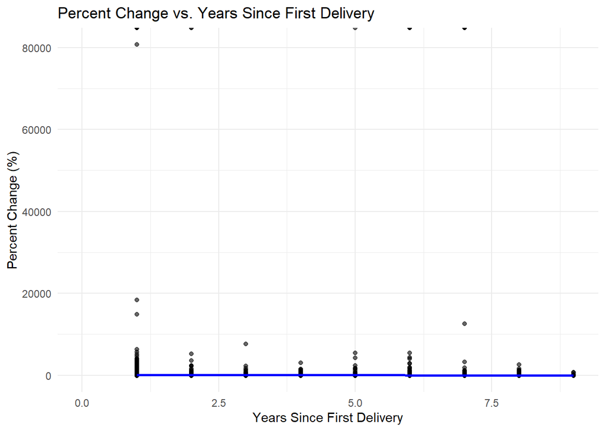

```r
# Scatter plot of years since first delivery vs. percent change
ggplot(customer_summary, aes(x = years_since_first_delivery, y = percent_change)) +
  geom_point(alpha = 0.6) +
  geom_smooth(method = "lm", color = "blue", se = TRUE) +  # Linear regression line
  labs(title = "Percent Change vs. Years Since First Delivery",
       x = "Years Since First Delivery",
       y = "Percent Change (%)") +
  theme_minimal()
```

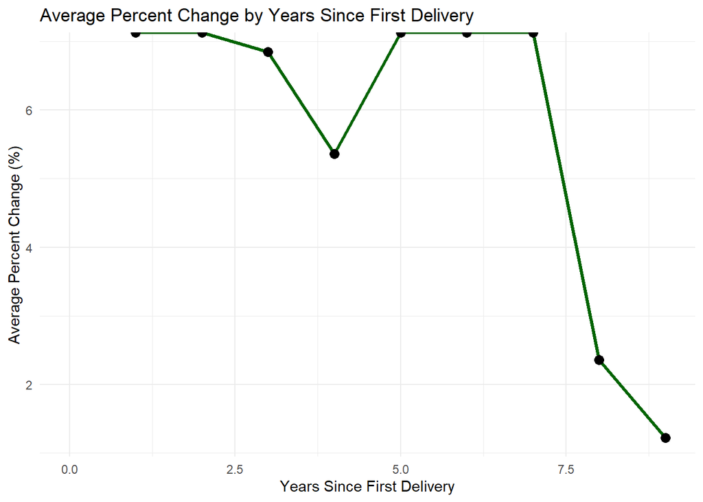

```r
# Line plot for average percent change over time
ggplot(summary_by_years, aes(x = years_since_first_delivery, y = avg_percent_change)) +
  geom_line(color = "darkgreen", size = 1.2) +
  geom_point(size = 3) +
  labs(title = "Average Percent Change by Years Since First Delivery",
       x = "Years Since First Delivery",
       y = "Average Percent Change (%)") +
  theme_minimal()
```

Merging the data back together.

### Trade Channels & Percent Change

#### Top Performing Channels (by average growth):

Outdoor Activities: Recorded an infinite (Inf) average percent change, likely due to extreme outliers. Bulk Trade: Showed the highest finite average growth at 111.40%, indicating substantial order increases. Activities (69.88%) and Mobile Retail (54.55%) also experienced notable growth.

#### Low or Negative Growth Channels:

Pharmacy Retailer: The only trade channel with negative average growth at -4.99%, indicating a decline in order volume. Large-Scale Retailer: Data was missing or non-finite for this category, possibly due to a small sample size (only 1 customer).

#### Median Percent Change:

Despite high average growth in some channels, the median percent change is often negative, indicating that while a few customers drive significant growth, the majority experience little or negative change. Healthcare and Travel stand out with positive medians, suggesting more consistent growth across customers within these channels.

```r
# Extract TRADE_CHANNEL from the original dataset
customer_trade_channels <- stg_cust_tran_clean %>%
  select(CUSTOMER_NUMBER, TRADE_CHANNEL) %>%
  distinct()  # Ensure one row per customer

# Join with pivoted dataset
customer_year_summary <- customer_year_summary %>%
  left_join(customer_trade_channels, by = "CUSTOMER_NUMBER")

# Group by TRADE_CHANNEL and summarize growth statistics
trade_channel_summary <- customer_year_summary %>%
  group_by(TRADE_CHANNEL) %>%
  summarise(
    avg_percent_change = mean(percent_change, na.rm = TRUE),
    median_percent_change = median(percent_change, na.rm = TRUE),
    count_customers = n()
  ) %>%
  arrange(desc(avg_percent_change))  # Sort by highest average growth

# Display the summary
trade_channel_summary
```

```
## # A tibble: 26 × 4
##    TRADE_CHANNEL        avg_percent_change median_percent_change count_customers
##    <fct>                             <dbl>                 <dbl>           <int>
##  1 OUTDOOR ACTIVITIES                Inf                    0               2189
##  2 BULK TRADE                        111.                  -6.04             105
##  3 ACTIVITIES                         69.9                 -1.23             299
##  4 MOBILE RETAIL                      54.6                 -8.86             372
##  5 RECREATION                         48.3                  1.65             830
##  6 OTHER DINING & BEVE…               39.5                 -3.64            2780
##  7 DEFENSE                            39.1                 -5.12             124
##  8 GENERAL                            36.8                  1.59            1223
##  9 FAST CASUAL DINING                 26.8                 -6.36            5990
## 10 PUBLIC SECTOR (NON-…               26.7                 -4.91             349
## # ℹ 16 more rows
```

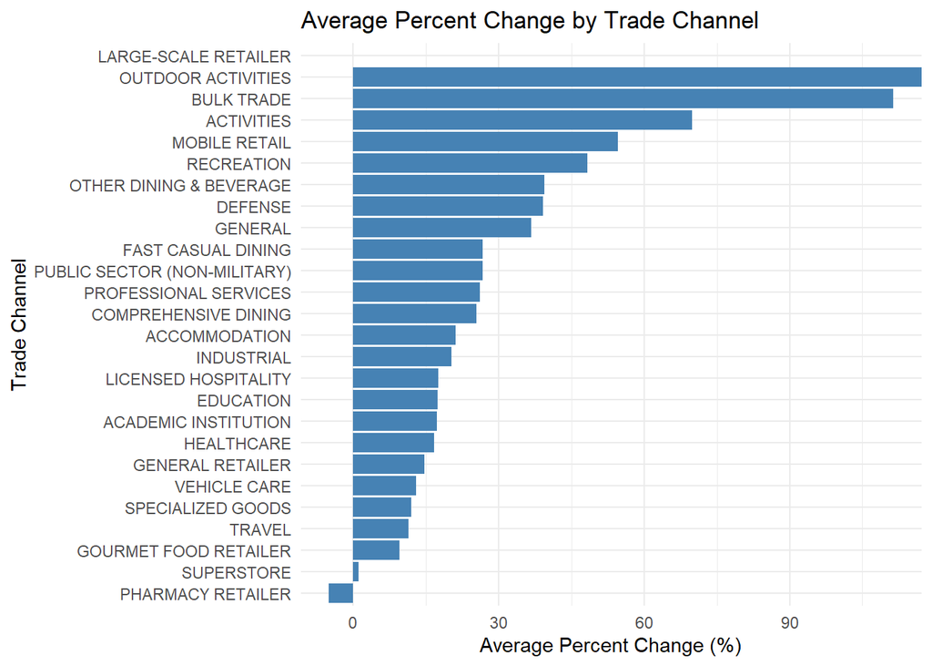

```r
# Bar Chart of Average Percent Change by Trade Channel
ggplot(trade_channel_summary, aes(x = reorder(TRADE_CHANNEL, avg_percent_change), y = avg_percent_change)) +
  geom_bar(stat = "identity", fill = "steelblue") +
  coord_flip() +  # Flip for better readability
  labs(title = "Average Percent Change by Trade Channel",
       x = "Trade Channel",
       y = "Average Percent Change (%)") +
  theme_minimal()
```

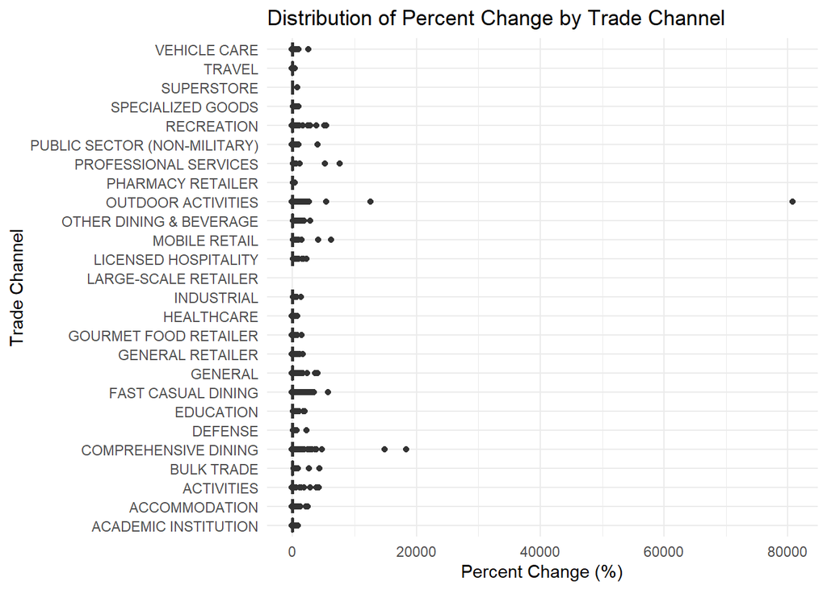

```r
# Boxplot to Show Distribution of Percent Change for Each Trade Channel
ggplot(customer_year_summary, aes(x = TRADE_CHANNEL, y = percent_change)) +
  geom_boxplot() +
  coord_flip() +
  labs(title = "Distribution of Percent Change by Trade Channel",
       x = "Trade Channel",
       y = "Percent Change (%)") +
  theme_minimal()
```

Verifying that each customer belongs to only 1 trade channel. If true, this can also be used as a predicting factor for Swire to help identify if certain trade channels can have an impact on growth.

```r
library(stringr)
# Count the number of distinct trade channels per customer (no filter)
trade_channel_count <- stg_cust_tran_clean %>%
  group_by(CUSTOMER_NUMBER) %>%
  summarise(unique_trade_channels = n_distinct(TRADE_CHANNEL)) %>%
  arrange(desc(unique_trade_channels))  # Sort in descending order

# Display the top customers with the most unique trade channels
head(trade_channel_count, 10)
```

```
## # A tibble: 10 × 2
##    CUSTOMER_NUMBER unique_trade_channels
##              <int>                 <int>
##  1       500245678                     1
##  2       500245685                     1
##  3       500245686                     1
##  4       500245687                     1
##  5       500245689                     1
##  6       500245690                     1
##  7       500245695                     1
##  8       500245698                     1
##  9       500245701                     1
## 10       500245704                     1
```

```r
# Extract distinct trade channels for each customer
customer_trade_channel_details <- stg_cust_tran_clean %>%
  select(CUSTOMER_NUMBER, TRADE_CHANNEL) %>%
  distinct() %>%
  group_by(CUSTOMER_NUMBER) %>%
  summarise(all_trade_channels = paste(unique(TRADE_CHANNEL), collapse = ", ")) %>%
  arrange(desc(str_count(all_trade_channels, ",")))  # Sort by number of channels

# Display the top customers
head(customer_trade_channel_details, 10)
```

```
## # A tibble: 10 × 2
##    CUSTOMER_NUMBER all_trade_channels
##              <int> <chr>
##  1       500245678 OUTDOOR ACTIVITIES
##  2       500245685 FAST CASUAL DINING
##  3       500245686 SPECIALIZED GOODS
##  4       500245687 OUTDOOR ACTIVITIES
##  5       500245689 LICENSED HOSPITALITY
##  6       500245690 FAST CASUAL DINING
##  7       500245695 HEALTHCARE
##  8       500245698 OTHER DINING & BEVERAGE
##  9       500245701 FAST CASUAL DINING
## 10       500245704 FAST CASUAL DINING
```

```r
#  Count the number of distinct trade channels per customer
multiple_trade_channels <- stg_cust_tran_clean %>%
  group_by(CUSTOMER_NUMBER) %>%
  summarise(unique_trade_channels = n_distinct(TRADE_CHANNEL)) %>%
  filter(unique_trade_channels > 1)  # Keep only customers with more than one trade channel

#  Display the results
multiple_trade_channels
```

```
## # A tibble: 0 × 2
## # ℹ 2 variables: CUSTOMER_NUMBER <int>, unique_trade_channels <int>
```

Adding the trade channel to the percentage change data.

```r
#  Drop ALL columns named TRADE_CHANNEL before joining
customer_year_summary <- customer_year_summary %>%
  select(-contains("TRADE_CHANNEL"), everything())

#  Extract unique CUSTOMER_NUMBER and TRADE_CHANNEL from the original dataset
customer_trade_channel <- stg_cust_tran_clean %>%
  select(CUSTOMER_NUMBER, TRADE_CHANNEL) %>%
  distinct()

#  Perform LEFT JOIN only once
customer_year_summary <- customer_year_summary %>%
  left_join(customer_trade_channel, by = "CUSTOMER_NUMBER")

#  Drop ALL columns named TRADE_CHANNEL.y before joining
customer_year_summary <- customer_year_summary %>%
  select(-contains("TRADE_CHANNEL.y"), everything())

#  Display the final dataset
head(customer_year_summary)
```

```
## # A tibble: 6 × 7
## # Groups:   CUSTOMER_NUMBER [6]
##   CUSTOMER_NUMBER total_order_2023 total_order_2024 percent_change
##             <int>            <dbl>            <dbl>          <dbl>
## 1       500245678            370              384.            3.65
## 2       500245685            602.             482           -19.9
## 3       500245686             17.5             18.5           5.71
## 4       500245687            125              148.           18
## 5       500245689            546.             621            13.6
## 6       500245690            325              300.           -7.54
## # ℹ 3 more variables: growth_category <chr>, TRADE_CHANNEL.x <fct>,
## #   TRADE_CHANNEL.y <fct>
```

## Additional Customer Feature Explortation

### CO2 Customers

There are significantly more FALSE instances (638,103) compared to TRUE (407,437). This suggests that the majority of customer records do not meet the CO2_CUSTOMER condition represented by TRUE. The ratio of FALSE to TRUE is approximately 1.57:1, indicating that for every customer record meeting the TRUE condition, there are about 1.57 records that do not.

```r
#  Count the number of distinct CO2_CUSTOMER values per customer
multiple_co2_values <- stg_cust_tran_clean %>%
  group_by(CUSTOMER_NUMBER) %>%
  summarise(unique_co2_values = n_distinct(CO2_CUSTOMER, na.rm = TRUE)) %>%
  filter(unique_co2_values > 1)  # Keep only customers with more than one distinct value

#  Display the result
multiple_co2_values
```

```
## # A tibble: 0 × 2
## # ℹ 2 variables: CUSTOMER_NUMBER <int>, unique_co2_values <int>
```

```r
#  Summarize total number of TRUE and FALSE values
co2_summary <- stg_cust_tran_clean %>%
  summarise(
    total_true = sum(CO2_CUSTOMER == TRUE, na.rm = TRUE),   # Count all TRUE
    total_false = sum(CO2_CUSTOMER == FALSE, na.rm = TRUE)  # Count all FALSE
  )

#  Display the result
co2_summary
```

```
##   total_true total_false
## 1     407437      638103
```

Adding the CO2 column into the data.

```r
#  Extract unique CUSTOMER_NUMBER and CO2_CUSTOMER from the original dataset
customer_co2 <- stg_cust_tran_clean %>%
  select(CUSTOMER_NUMBER, CO2_CUSTOMER) %>%
  distinct()

#  LEFT JOIN to add CO2_CUSTOMER to the customer_year_summary dataset
customer_year_summary <- customer_year_summary %>%
  left_join(customer_co2, by = "CUSTOMER_NUMBER")

#  Drop ALL columns named TRADE_CHANNEL.y before joining
customer_year_summary <- customer_year_summary %>%
  select(-contains("TRADE_CHANNEL.y"), everything())

# : Display the updated dataset
head(customer_year_summary)
```

```
## # A tibble: 6 × 8
## # Groups:   CUSTOMER_NUMBER [6]
##   CUSTOMER_NUMBER total_order_2023 total_order_2024 percent_change
##             <int>            <dbl>            <dbl>          <dbl>
## 1       500245678            370              384.            3.65
## 2       500245685            602.             482           -19.9
## 3       500245686             17.5             18.5           5.71
## 4       500245687            125              148.           18
## 5       500245689            546.             621            13.6
## 6       500245690            325              300.           -7.54
## # ℹ 4 more variables: growth_category <chr>, TRADE_CHANNEL.x <fct>,
## #   CO2_CUSTOMER <lgl>, TRADE_CHANNEL.y <fct>
```

### Cold Drink Channel

Customers exclusively interact within a single channel, suggesting highly segmented customer behavior. Channels with fewer unique customers (i.e. WELLNESS, CONVENTIONAL) may offer growth potential, either by expanding the customer base or increasing engagement within existing customers.

This may indicate prioritizing channels like DINING and GOODS due to their higher engagement levels, while developing strategies to boost performance in lower-engagement channels like WELLNESS and CONVENTIONAL.

```r
#  Summarize total counts and unique customer counts for each COLD_DRINK_CHANNEL
cold_drink_summary <- stg_cust_tran_clean %>%
  group_by(COLD_DRINK_CHANNEL) %>%                         # Group by channel
  summarise(
    total_count = n(),                                     # Count total records
    unique_customers = n_distinct(CUSTOMER_NUMBER)         # Count unique customers
  ) %>%
  arrange(desc(total_count))                               # Sort by total count in descending order

#  Display the result
cold_drink_summary
```

```
## # A tibble: 9 × 3
##   COLD_DRINK_CHANNEL total_count unique_customers
##   <fct>                    <int>            <int>
## 1 DINING                  527910            15401
## 2 GOODS                   173384             5826
## 3 EVENT                    96258             3074
## 4 BULK TRADE               87527             1320
## 5 PUBLIC SECTOR            53937             1736
## 6 ACCOMMODATION            44330             1235
## 7 WORKPLACE                33004             1194
## 8 WELLNESS                 27950              479
## 9 CONVENTIONAL              1240               57
```

```r
#  Count unique COLD_DRINK_CHANNEL per customer
customer_channel_count <- stg_cust_tran_clean %>%
  group_by(CUSTOMER_NUMBER) %>%                              # Group by customer
  summarise(unique_channels = n_distinct(COLD_DRINK_CHANNEL))# Count unique channels

#  Count how many customers have more than one channel
multiple_channel_count <- customer_channel_count %>%
  filter(unique_channels > 1) %>%                            # Filter for >1 channel
  summarise(count_customers = n())                           # Count number of customers

#  Display result
multiple_channel_count
```

```
## # A tibble: 1 × 1
##   count_customers
##             <int>
## 1               0
```

Adding cold drink channel to the data set.

```r
#  Extract unique CUSTOMER_NUMBER and COLD_DRINK_CHANNEL from the original dataset
customer_cold_drink_channel <- stg_cust_tran_clean %>%
  select(CUSTOMER_NUMBER, COLD_DRINK_CHANNEL) %>%
  distinct()

#  LEFT JOIN to add COLD_DRINK_CHANNEL to the customer_year_summary dataset
customer_year_summary <- customer_year_summary %>%
  left_join(customer_cold_drink_channel, by = "CUSTOMER_NUMBER")

# Display the updated dataset
head(customer_year_summary)
```

```
## # A tibble: 6 × 9
## # Groups:   CUSTOMER_NUMBER [6]
##   CUSTOMER_NUMBER total_order_2023 total_order_2024 percent_change
##             <int>            <dbl>            <dbl>          <dbl>
## 1       500245678            370              384.            3.65
## 2       500245685            602.             482           -19.9
## 3       500245686             17.5             18.5           5.71
## 4       500245687            125              148.           18
## 5       500245689            546.             621            13.6
## 6       500245690            325              300.           -7.54
## # ℹ 5 more variables: growth_category <chr>, TRADE_CHANNEL.x <fct>,
## #   CO2_CUSTOMER <lgl>, TRADE_CHANNEL.y <fct>, COLD_DRINK_CHANNEL <fct>
```

### Sub-trade Channel

```r
# Summary statistics - count of each SUB_TRADE_CHANNEL
sub_trade_channel_summary <- stg_cust_tran_clean %>%
  count(SUB_TRADE_CHANNEL, name = "count") %>%  # Count occurrences
  arrange(desc(count))  # Sort in descending order

#  Distribution as percentages
sub_trade_channel_distribution <- sub_trade_channel_summary %>%
  mutate(percent = count / sum(count) * 100)  # Calculate percentage

#  Display both datasets
list(summary = sub_trade_channel_summary, distribution = sub_trade_channel_distribution)
```

```
## $summary
##              SUB_TRADE_CHANNEL  count
## 1                   FSR - MISC 164577
## 2              PIZZA FAST FOOD  85797
## 3       COMPREHENSIVE PROVIDER  72588
## 4                 OTHER DINING  70562
## 5         OTHER GENERAL RETAIL  64574
## 6            MEXICAN FAST FOOD  57834
## 7              OTHER FAST FOOD  55909
## 8     OTHER OUTDOOR ACTIVITIES  54610
## 9          OTHER ACCOMMODATION  44426
## 10             HOME & HARDWARE  39366
## 11          OTHER VEHICLE CARE  38966
## 12  OTHER LICENSED HOSPITALITY  37650
## 13            OTHER HEALTHCARE  27513
```

[output cut: 86 more lines]

```r
#  Count distinct SUB_TRADE_CHANNEL per CUSTOMER_NUMBER
sub_trade_channel_count <- stg_cust_tran_clean %>%
  group_by(CUSTOMER_NUMBER) %>%
  summarise(unique_sub_trade_channel = n_distinct(SUB_TRADE_CHANNEL)) %>%
  ungroup()

#  Count the number of customers with more than one SUB_TRADE_CHANNEL
multiple_sub_trade_channel_count <- sub_trade_channel_count %>%
  filter(unique_sub_trade_channel > 1) %>%
  summarise(total_customers_with_multiple_channels = n())

#  Display the count
multiple_sub_trade_channel_count
```

```
## # A tibble: 1 × 1
##   total_customers_with_multiple_channels
##                                    <int>
## 1                                      0
```

```r
# Extract unique CUSTOMER_NUMBER and SUB_TRADE_CHANNEL
customer_sub_trade_channel <- stg_cust_tran_clean %>%
  select(CUSTOMER_NUMBER, SUB_TRADE_CHANNEL) %>%
  distinct()

# LEFT JOIN to add SUB_TRADE_CHANNEL
customer_year_summary <- customer_year_summary %>%
  left_join(customer_sub_trade_channel, by = "CUSTOMER_NUMBER")

#  Drop TRADE_CHANNEL.y column if it exists
customer_year_summary <- customer_year_summary %>%
  select(-contains("TRADE_CHANNEL.y"), everything())

#  Display the updated dataset
head(customer_year_summary)
```

```
## # A tibble: 6 × 10
## # Groups:   CUSTOMER_NUMBER [6]
##   CUSTOMER_NUMBER total_order_2023 total_order_2024 percent_change
##             <int>            <dbl>            <dbl>          <dbl>
## 1       500245678            370              384.            3.65
## 2       500245685            602.             482           -19.9
## 3       500245686             17.5             18.5           5.71
## 4       500245687            125              148.           18
## 5       500245689            546.             621            13.6
## 6       500245690            325              300.           -7.54
## # ℹ 6 more variables: growth_category <chr>, TRADE_CHANNEL.x <fct>,
## #   CO2_CUSTOMER <lgl>, COLD_DRINK_CHANNEL <fct>, SUB_TRADE_CHANNEL <fct>,
## #   TRADE_CHANNEL.y <fct>
```

### Local Market Partners

TRUE records significantly outnumber FALSE records suggests that the majority of customer transactions involve local market partnerships.

```r
# Summarize LOCAL_MARKET_PARTNER counts
local_market_summary <- stg_cust_tran_clean %>%
  summarise(
    total_true = sum(LOCAL_MARKET_PARTNER == TRUE, na.rm = TRUE),
    total_false = sum(LOCAL_MARKET_PARTNER == FALSE, na.rm = TRUE),
    total_customers = n_distinct(CUSTOMER_NUMBER),
    percent_true = (total_true / (total_true + total_false)) * 100,  # Corrected calculation
    percent_false = (total_false / (total_true + total_false)) * 100 # Corrected calculation
  )

# Display result
local_market_summary
```

```
##   total_true total_false total_customers percent_true percent_false
## 1     860699      184841           30322       82.321        17.679
```

```r
 # Extract unique CUSTOMER_NUMBER and LOCAL_MARKET_PARTNER
customer_local_market <- stg_cust_tran_clean %>%
  select(CUSTOMER_NUMBER, LOCAL_MARKET_PARTNER) %>%
  distinct()

# LEFT JOIN to add LOCAL_MARKET_PARTNER
customer_year_summary <- customer_year_summary %>%
  left_join(customer_local_market, by = "CUSTOMER_NUMBER")

#  Drop TRADE_CHANNEL.y column if it exists
customer_year_summary <- customer_year_summary %>%
  select(-contains("TRADE_CHANNEL.y"), everything())

# Display the updated dataset
head(customer_year_summary)
```

```
## # A tibble: 6 × 11
## # Groups:   CUSTOMER_NUMBER [6]
##   CUSTOMER_NUMBER total_order_2023 total_order_2024 percent_change
##             <int>            <dbl>            <dbl>          <dbl>
## 1       500245678            370              384.            3.65
## 2       500245685            602.             482           -19.9
## 3       500245686             17.5             18.5           5.71
## 4       500245687            125              148.           18
## 5       500245689            546.             621            13.6
## 6       500245690            325              300.           -7.54
## # ℹ 7 more variables: growth_category <chr>, TRADE_CHANNEL.x <fct>,
## #   CO2_CUSTOMER <lgl>, COLD_DRINK_CHANNEL <fct>, SUB_TRADE_CHANNEL <fct>,
## #   LOCAL_MARKET_PARTNER <lgl>, TRADE_CHANNEL.y <fct>
```

### Order Types

The dataset contains 6 distinct FREQUENT_ORDER_TYPEs.

#### Order Value Comparison:

EDI has the highest average order total (39.5), which may reflect larger, bulk orders. CALL CENTER has the lowest average order total (13.9), suggesting smaller, potentially one-off or urgent orders.

#### Online Ordering Platforms (MYCOKE360 and MYCOKE LEGACY):

Both platforms have relatively low average order totals (20.6 and 20.0, respectively), which could indicate that online customers place smaller, more frequent orders.

```r
#  Summarize the count of each FREQUENT_ORDER_TYPE
frequent_order_summary <- stg_cust_tran_clean %>%
  group_by(FREQUENT_ORDER_TYPE) %>%
  summarise(
    total_customers = n_distinct(CUSTOMER_NUMBER),  # Unique customers
    total_orders = n(),  # Total number of orders
    avg_order_total = mean(ordered_Total, na.rm = TRUE),  # Average order value
    median_order_total = median(ordered_Total, na.rm = TRUE)  # Median order value
  ) %>%
  arrange(desc(total_orders))

#  Display results
print(frequent_order_summary)
```

```
## # A tibble: 6 × 5
##   FREQUENT_ORDER_TYPE total_customers total_orders avg_order_total
##   <fct>                         <int>        <int>           <dbl>
## 1 SALES REP                     19929       749299            38.4
## 2 OTHER                          5338       187002            39.4
## 3 MYCOKE360                      2385        46780            20.6
## 4 CALL CENTER                    1355        26420            13.9
## 5 MYCOKE LEGACY                   974        24523            20.0
## 6 EDI                             341        11516            39.5
## # ℹ 1 more variable: median_order_total <dbl>
```

```r
#  Extract unique CUSTOMER_NUMBER and FREQUENT_ORDER_TYPE
customer_frequent_order <- stg_cust_tran_clean %>%
  select(CUSTOMER_NUMBER, FREQUENT_ORDER_TYPE) %>%
  distinct()

#  LEFT JOIN to add FREQUENT_ORDER_TYPE to customer_year_summary
customer_year_summary <- customer_year_summary %>%
  left_join(customer_frequent_order, by = "CUSTOMER_NUMBER")

# S Drop TRADE_CHANNEL.y if it exists
customer_year_summary <- customer_year_summary %>%
  select(-contains("TRADE_CHANNEL.y"), everything())

#  Display the updated dataset
head(customer_year_summary)
```

```
## # A tibble: 6 × 12
## # Groups:   CUSTOMER_NUMBER [6]
##   CUSTOMER_NUMBER total_order_2023 total_order_2024 percent_change
##             <int>            <dbl>            <dbl>          <dbl>
## 1       500245678            370              384.            3.65
## 2       500245685            602.             482           -19.9
## 3       500245686             17.5             18.5           5.71
## 4       500245687            125              148.           18
## 5       500245689            546.             621            13.6
## 6       500245690            325              300.           -7.54
## # ℹ 8 more variables: growth_category <chr>, TRADE_CHANNEL.x <fct>,
## #   CO2_CUSTOMER <lgl>, COLD_DRINK_CHANNEL <fct>, SUB_TRADE_CHANNEL <fct>,
## #   LOCAL_MARKET_PARTNER <lgl>, FREQUENT_ORDER_TYPE <fct>,
## #   TRADE_CHANNEL.y <fct>
```

#### Order Type Diversity Varies Among Customers:

Some customers use only a single order type, while others utilize up to four different types. The maximum number of distinct order types in this sample is 4, suggesting a moderate level of order type variety within the dataset.

#### Single vs. Multiple Order Types:

Customers with 1 distinct order type may have more straightforward and predictable purchasing behavior. Customers with multiple order types might represent more complex or diverse needs, possibly ordering through different channels or for various purposes.

#### Potential for Cross-Selling:

Customers using fewer order types could be targeted for cross-selling opportunities by promoting the benefits of additional order types.

Conversely, customers with multiple order types might be key accounts with diverse purchasing patterns, warranting personalized engagement strategies.

```r
#  Count the number of distinct ORDER_TYPE values per customer
order_type_count <- stg_cust_tran_clean %>%
  group_by(CUSTOMER_NUMBER) %>%
  summarise(distinct_order_types = n_distinct(ORDER_TYPE, na.rm = TRUE)) %>%
  ungroup()

#  Display the result
head(order_type_count)
```

```
## # A tibble: 6 × 2
##   CUSTOMER_NUMBER distinct_order_types
##             <int>                <int>
## 1       500245678                    3
## 2       500245685                    2
## 3       500245686                    1
## 4       500245687                    1
## 5       500245689                    2
## 6       500245690                    4
```

#### Customer Engagement Across Multiple Order Types:

Multi-order customers place orders through different channels, indicating diverse needs or purchasing behaviors. The SALES REP and MYCOKE LEGACY order types seem to generate higher total amounts, suggesting these are preferred channels.

#### Potential Data Issues:

The presence of null in the ORDER_TYPE field suggests missing or unclassified data that may require investigation. Orders with zero amounts could be test records or incomplete transactions that should be filtered out in future analyses.

```r
# Step 1: Identify customers with more than one order type
multi_order_customers <- stg_cust_tran_clean %>%
  group_by(CUSTOMER_NUMBER) %>%
  summarise(distinct_order_types = n_distinct(ORDER_TYPE, na.rm = TRUE)) %>%
  filter(distinct_order_types > 1) %>%
  pull(CUSTOMER_NUMBER)

# Step 2: Get the order types and their amounts for those customers
order_type_details <- stg_cust_tran_clean %>%
  filter(CUSTOMER_NUMBER %in% multi_order_customers) %>%
  group_by(CUSTOMER_NUMBER, ORDER_TYPE) %>%
  summarise(total_amount = sum(ordered_Total, na.rm = TRUE), .groups = "drop") %>%
  arrange(CUSTOMER_NUMBER, desc(total_amount))

# Step 3: Display the result
head(order_type_details)
```

```
## # A tibble: 6 × 3
##   CUSTOMER_NUMBER ORDER_TYPE    total_amount
##             <int> <fct>                <dbl>
## 1       500245678 SALES REP            721
## 2       500245678 CALL CENTER           32.5
## 3       500245678 null                   0
## 4       500245685 MYCOKE LEGACY        871
## 5       500245685 CALL CENTER          212.
## 6       500245689 MYCOKE LEGACY        929
```

```r
summary(order_type_details)
```

```
##  CUSTOMER_NUMBER             ORDER_TYPE     total_amount
##  Min.   :500245678   CALL CENTER  :10678   Min.   :     0.0
##  1st Qu.:501154158   EDI          :  399   1st Qu.:    20.0
##  Median :501527091   MYCOKE LEGACY:11930   Median :    75.0
##  Mean   :536644358   MYCOKE360    : 9800   Mean   :   584.0
##  3rd Qu.:600073211   null         : 3280   3rd Qu.:   287.5
##  Max.   :600975408   OTHER        : 4399   Max.   :658625.0
##                      SALES REP    :11263
```

```r
# Pivot the data
order_type_details_pivot <- order_type_details %>%
  pivot_wider(names_from = ORDER_TYPE, values_from = total_amount, values_fill = 0)

# Display the result
head(order_type_details_pivot)
```

```
## # A tibble: 6 × 8
##   CUSTOMER_NUMBER `SALES REP` `CALL CENTER`  null `MYCOKE LEGACY` MYCOKE360
##             <int>       <dbl>         <dbl> <dbl>           <dbl>     <dbl>
## 1       500245678         721          32.5     0              0         0
## 2       500245685           0         212.      0            871         0
## 3       500245689           0           0       0            929       238.
## 4       500245690           1          10       0            516.       98
## 5       500245695           0           0       0           1562.      282.
## 6       500245698           0         498.      0            229       643
## # ℹ 2 more variables: OTHER <dbl>, EDI <dbl>
```

```r
#  Left join the pivoted order type columns to the main dataset
customer_year_summary <- customer_year_summary %>%
  left_join(order_type_details_pivot, by = "CUSTOMER_NUMBER")

#  Display the updated dataset
head(customer_year_summary)
```

```
## # A tibble: 6 × 19
## # Groups:   CUSTOMER_NUMBER [6]
##   CUSTOMER_NUMBER total_order_2023 total_order_2024 percent_change
##             <int>            <dbl>            <dbl>          <dbl>
## 1       500245678            370              384.            3.65
## 2       500245685            602.             482           -19.9
## 3       500245686             17.5             18.5           5.71
## 4       500245687            125              148.           18
## 5       500245689            546.             621            13.6
## 6       500245690            325              300.           -7.54
## # ℹ 15 more variables: growth_category <chr>, TRADE_CHANNEL.x <fct>,
## #   CO2_CUSTOMER <lgl>, COLD_DRINK_CHANNEL <fct>, SUB_TRADE_CHANNEL <fct>,
## #   LOCAL_MARKET_PARTNER <lgl>, FREQUENT_ORDER_TYPE <fct>,
## #   TRADE_CHANNEL.y <fct>, `SALES REP` <dbl>, `CALL CENTER` <dbl>, null <dbl>,
## #   `MYCOKE LEGACY` <dbl>, MYCOKE360 <dbl>, OTHER <dbl>, EDI <dbl>
```